# CSCI E-63C: Week 1 Q&A session

```r
library(ISLR)
library(RColorBrewer)
library(reshape2)
library(ggplot2)
knitr::opts_chunk$set(echo = TRUE)
```

# Install R

Available at https://www.r-project.org/

# Install Rstudio

Available at https://www.rstudio.com/

# Install packages

ISLR, ggplot2, reshape2, RColorBrewer

# “Knit HTML”

- Just a button in Rstudio
- Good starting point is “File->New File->R Markdown…”, follow prompts and then “Knit HTML”

# Homework and quiz

- 60 points for coding assignment, 40 points for quiz
- here we’ll review the main points of coding assignment
- quiz is designed to prompt review of the lecture / suggested reading
- if you find yourself googling, you must be overthinking it
- reach out on piazza (as a private question if your prefer)
- *SIGN-UP TO PIAZZA IF YOU HAVEN’T YET*
- midterm and final exams will be also take home week long data analysis projects
- no quiz as part of midterm/final

# Q&A topics

- How to …?
- How come R …?
- Why statistical learning …?
- `?help` vs `help` vs `help()`
- “An Introduction to R” by `help.start()`
- Google
- O’Reilly “R cookbook” by Paul Teetor
- http://www.nytimes.com/2009/01/07/technology/business-computing/07program.html (NYT version)
- http://arrgh.tim-smith.us/ (some cathartic reading for those who programmed in other languages):
  - “R is a shockingly dreadful language for an exceptionally useful data analysis environment”

# R caveats

- R assumes for you a lot
- converts types for you
- type checking
- Rather than “if it compiles, it works”, “if it works, still check the results”,
- factors!!!
- What can be worse than global variables? “.RData”, of course!
- `save()` computationally expensive results
- plenty of others…

# Some of the good practices

- literate programming/reproducible research (knitr, sweave, rstudio)
- paying attention to warnings, building gradually, testing all along
- more efficient when vectorized, simulation in a matrix
- there are profiling tools (e.g. http://adv-r.had.co.nz/Profiling.html), but then remember Donald Knuth’s view on premature optimization
- Use functions: they promote code reuse and help cutting down on global variables

# Example of the effect of vectorization

```r
x <- matrix(rnorm(50000*10),ncol=10)
y <- numeric(); pt1 <- proc.time()
for ( i in 1:dim(x)[1] ) y[i] <- mean(x[i,])
pt2 <- proc.time(); pt2-pt1; y[1:3]
```

```
##    user  system elapsed
##   0.212   0.008   0.221
```

```
## [1] -0.06586013  0.08739853 -0.49471660
```

```r
y <- apply(x,1,mean)
pt3 <- proc.time(); pt3 - pt2; y[1:3]
```

```
##    user  system elapsed
##   0.255   0.003   0.260
```

```
## [1] -0.06586013  0.08739853 -0.49471660
```

```r
y <- rowMeans(x)
proc.time() - pt3; y[1:3]
```

```
##    user  system elapsed
##   0.005   0.000   0.006
```

```
## [1] -0.06586013  0.08739853 -0.49471660
```

# Plots from ISLR Ch. 1

## Plots from Fig.1.1

```r
class(Wage)
```

```
## [1] "data.frame"
```

```r
dim(Wage)
```

```
## [1] 3000   12
```

```r
nrow(Wage)
```

```
## [1] 3000
```

```r
ncol(Wage)
```

```
## [1] 12
```

```r
head(Wage)
```

```
##        year age     sex           maritl     race       education
## 231655 2006  18 1. Male 1. Never Married 1. White    1. < HS Grad
## 86582  2004  24 1. Male 1. Never Married 1. White 4. College Grad
## 161300 2003  45 1. Male       2. Married 1. White 3. Some College
## 155159 2003  43 1. Male       2. Married 3. Asian 4. College Grad
## 11443  2005  50 1. Male      4. Divorced 1. White      2. HS Grad
## 376662 2008  54 1. Male       2. Married 1. White 4. College Grad
##                    region       jobclass         health health_ins
## 231655 2. Middle Atlantic  1. Industrial      1. <=Good      2. No
## 86582  2. Middle Atlantic 2. Information 2. >=Very Good      2. No
## 161300 2. Middle Atlantic  1. Industrial      1. <=Good     1. Yes
## 155159 2. Middle Atlantic 2. Information 2. >=Very Good     1. Yes
## 11443  2. Middle Atlantic 2. Information      1. <=Good     1. Yes
## 376662 2. Middle Atlantic 2. Information 2. >=Very Good     1. Yes
##         logwage      wage
## 231655 4.318063  75.04315
## 86582  4.255273  70.47602
## 161300 4.875061 130.98218
## 155159 5.041393 154.68529
## 11443  4.318063  75.04315
## 376662 4.845098 127.11574
```

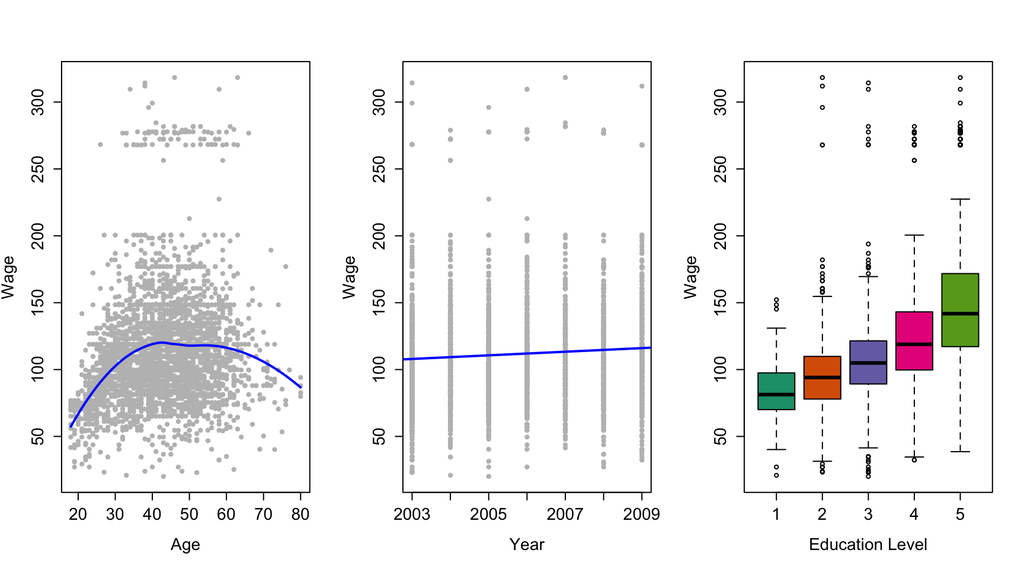

```r
old.par <- par(mfrow=c(1,3),ps=16)
plot(Wage[,c("age","wage")],xlab="Age",ylab="Wage",pch=20,col="gray")
points(min(Wage$age):max(Wage$age),predict(loess(wage~age,Wage),newdata=data.frame(age=min(Wage$age):max(Wage$age))),col="blue",type="l",lwd=2)
plot(Wage[,c("year","wage")],xlab="Year",ylab="Wage",pch=20,col="gray")
abline(lm(wage~year,Wage),col="blue",lwd=2)
boxplot(wage~substring(education,1,1),Wage,col=brewer.pal(5,"Dark2"),xlab="Education Level",ylab="Wage")  #YlGnBu RdYlGn Accent
```

```r
par(old.par)
```

## Plots from Fig.1.2

```
## [1] "data.frame"
```

```
## [1] 1250    9
```

```
##       Year           Lag1                Lag2
##  Min.   :2001   Min.   :-4.922000   Min.   :-4.922000
##  1st Qu.:2002   1st Qu.:-0.639500   1st Qu.:-0.639500
##  Median :2003   Median : 0.039000   Median : 0.039000
##  Mean   :2003   Mean   : 0.003834   Mean   : 0.003919
##  3rd Qu.:2004   3rd Qu.: 0.596750   3rd Qu.: 0.596750
##  Max.   :2005   Max.   : 5.733000   Max.   : 5.733000
##       Lag3                Lag4                Lag5
##  Min.   :-4.922000   Min.   :-4.922000   Min.   :-4.92200
##  1st Qu.:-0.640000   1st Qu.:-0.640000   1st Qu.:-0.64000
##  Median : 0.038500   Median : 0.038500   Median : 0.03850
##  Mean   : 0.001716   Mean   : 0.001636   Mean   : 0.00561
##  3rd Qu.: 0.596750   3rd Qu.: 0.596750   3rd Qu.: 0.59700
##  Max.   : 5.733000   Max.   : 5.733000   Max.   : 5.73300
##      Volume           Today           Direction
##  Min.   :0.3561   Min.   :-4.922000   Down:602
##  1st Qu.:1.2574   1st Qu.:-0.639500   Up  :648
##  Median :1.4229   Median : 0.038500
##  Mean   :1.4783   Mean   : 0.003138
##  3rd Qu.:1.6417   3rd Qu.: 0.596750
##  Max.   :3.1525   Max.   : 5.733000
```

```
##   Year   Lag1   Lag2   Lag3   Lag4   Lag5 Volume  Today Direction
## 1 2001  0.381 -0.192 -2.624 -1.055  5.010 1.1913  0.959        Up
## 2 2001  0.959  0.381 -0.192 -2.624 -1.055 1.2965  1.032        Up
## 3 2001  1.032  0.959  0.381 -0.192 -2.624 1.4112 -0.623      Down
## 4 2001 -0.623  1.032  0.959  0.381 -0.192 1.2760  0.614        Up
## 5 2001  0.614 -0.623  1.032  0.959  0.381 1.2057  0.213        Up
## 6 2001  0.213  0.614 -0.623  1.032  0.959 1.3491  1.392        Up
```

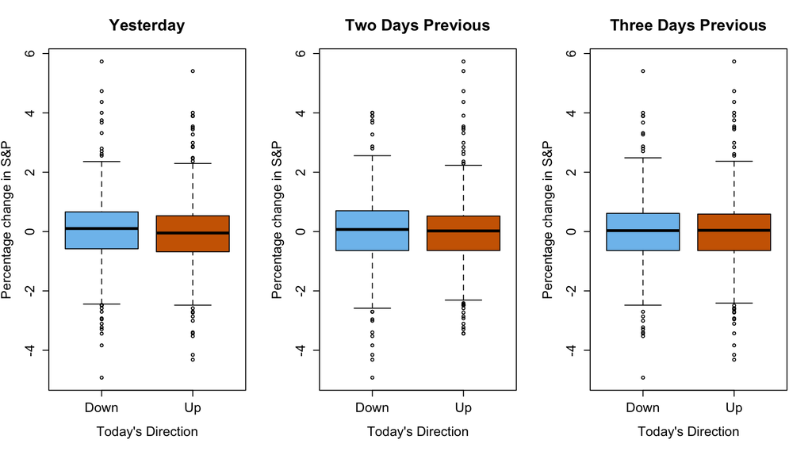

Similar plots by `ggplot`:

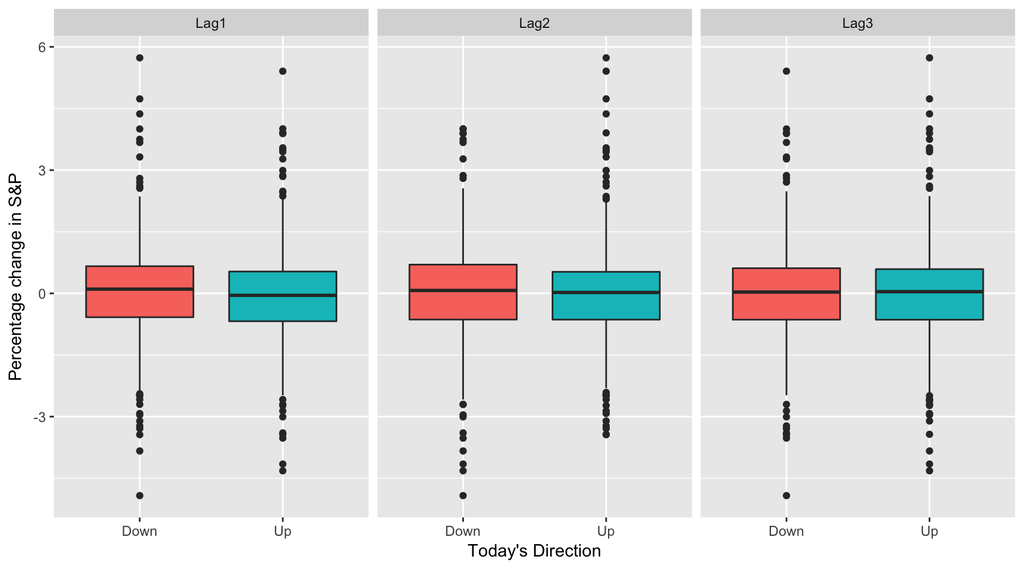

```r
ggplot(melt(Smarket[,c("Direction",paste0("Lag",1:3))]),aes(x=Direction,y=value,fill=Direction))+geom_boxplot()+facet_wrap(~variable)+theme(legend.position="none")+xlab("Today's Direction")+ylab("Percentage change in S&P")
```

# More useful pointers / food for thought

- [“50 years of Data Science”](http://courses.csail.mit.edu/18.337/2015/docs/50YearsDataScience.pdf)
- [“Classifier Technology and the Illusion of Progress”](https://arxiv.org/pdf/math/0606441.pdf)
- [“Statistical Modeling: The Two Cultures”](https://projecteuclid.org/download/pdf_1/euclid.ss/1009213726)
- [“ASA statement on p-values”](http://amstat.tandfonline.com/doi/full/10.1080/00031305.2016.1154108)
- [Replication crisis and reproducible research](http://simplystatistics.org/2016/08/24/replication-crisis/)
- Other examples of data analysis debacles: Duke chemosensitivity, etc.
- *“Essentially, all models are wrong, but some are useful”* **[George E. P. Box]**
- *“There is no true interpretation of anything; interpretation is a vehicle in the service of human comprehension. The value of interpretation is in enabling others to fruitfully think about an idea.”* **[Andreas Buja]**